# Fertility and Wealth: Causal Evidence

Work in progress

Edison Choque Sanchez

30/5/2022

# 1. Introduction

In this file we show the process to estimate the causal effect from fertility to household wealth. This process has three stages. First, we import the data base and explore it, but also we generate a subset of the data base because women are the group of analysis. Second, all the variable of interest should be created. For instance most of them should be transformed into the correct format. Finally, we show the result according to the model.

# 2. Data Generation

DHS surveys collect primary data using several types of questionnaires. A household questionnaire is used to collect information on characteristics of the household’s dwelling unit, and data related to the height and weight for women and children in the household. It is also used to identify members of the household who are eligible for an individual interview. Eligible respondents are then interviewed using an individual questionnaire.

In a majority of DHS surveys eligible individuals include women of reproductive age (15-49) and men age 15-59, or in some cases 15-54. In some countries only women are interviewed. Individual questionnaires include information on fertility, family planning and maternal and child health.

We use the individual record data. It mean that all women between 15 - 49 years old were interviewed. You can visit the following website to know about DHS program and data. [DHS program](https://dhsprogram.com/data/Getting-Started.cfm)

## Import data

```r
setwd("J:/Mi unidad/Consultorias/Gus_Canavire/ProyectoDHS/Data/2008")
dir()
```

```
## [1] "BOHR51FL.DTA" "BOIR51FL.DTA" "BOPR51FL.DTA"
```

```r
bdd_ir <- read.dta13("BOIR51FL.DTA", convert.factors = T)
```

## Data generation

In order to study and specific data, First, we select all variables that we consider to study. Second, we choose all the observation related with the female head of the household or the wife.

The selection of the principal variables is described in the next chunk. But also, is described how we select only the observations for wife or female head.

```r
ir1 <-  select(bdd_ir, caseid,v002,v003, v005, v012, v013, v133, v135, v137,
               v139, v150, v151,
               v152,v201, v219, v376, v605, v602,v616,
               v191,v190, v218, v731)
ir1 <- filter(ir1, v150=="wife or husband" | v150=="head")
```

To know the definition of these variables, we suggest to download the pdf files from the following link: [Files](https://dhsprogram.com/publications/publication-dhsg4-dhs-questionnaires-and-manuals.cfm). Once you enter to the link, download two pdf files: DHS-V Recode Manual and DHS-V Recode Map. In both you can find more information about the variables and data structure.

# 3. Creation of variables

the following variables are created for the 2SLS model. Most of them are changed to the correct format.

```r
ir1<- ir1 %>% mutate(infertility1 = v376 %in% 24) #v376 - Main reason not to use a meth.
ir1$infertility1_a=as.numeric(ir1$infertility1)

ir1<- ir1 %>% mutate(infertility2 = v602 %in% 5) # v602 - Fertility preference
ir1$infertility2_a=as.numeric(ir1$infertility2)

ir1$children <-  recode(ir1$v218, `0`=0L, `1`=1L, `2`=1L, `3`=1L, `4`=1L, `5`=1L,
                        `6`=1L, `7`=1L, `8`=1L,`9`=1L, `10`=1L,`11`=1L,
                        `12`=1L, `13`=1L, `14`=1L) # v218- Number of living children

v2 <- c("poorest", "poorer")
ir1<- ir1 %>% mutate(wealth = v190 %in% v2) # v190 - Wealth index
ir1$wealth_a<- as.numeric(ir1$wealth) # wealth_a -  1 "poorest - poorer" 0 is "middle - richer- richest"

m1 <- c("la paz", "oruro", "potosí")
m2 <- c("cochabamba", "chuquisaca", "tarija")
m3 <- c("pando", "beni", "santa cruz")
ir1 <- ir1 %>% mutate(altiplano =v139 %in% m1,
      valle =v139 %in% m2, llano=v139 %in% m3) # v139 - De jure region of residence
ir1$altiplano_a<- as.numeric(ir1$altiplano)
ir1$valle_a<- as.numeric(ir1$valle)
ir1$llano_a<- as.numeric(ir1$llano)
```

# 4. Description of the **ir1** data base

First, we explore the dependent variable that is the Wealth index factor score, but also the binary variable *wealth_a*.

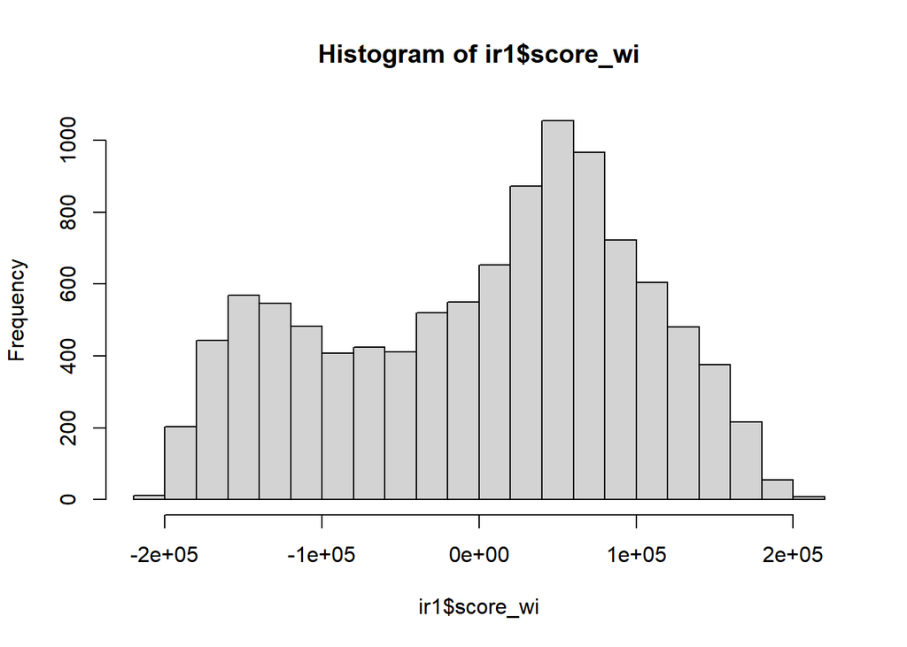

```r
ir1 <- ir1 %>% rename(score_wi=v191) #v191 - Wealth index factor score
hist(ir1$score_wi)
```

```r
summary(ir1$score_wi)
```

```
##    Min. 1st Qu.  Median    Mean 3rd Qu.    Max.
## -207701  -80956   22063    1808   75824  209794
```

```r
table(ir1$wealth_a)
```

```
##
##    0    1
## 6627 3946
```

Second, we describe the endogenous variable that is fertility, that is number of living children. We can define this variable in different ways. See some of these options:

```r
table(ir1$children)
```

```
##
##    0    1
##  797 9776
```

```r
table(ir1$v218)
```

```
##
##    0    1    2    3    4    5    6    7    8    9   10   11   12   13   14
##  797 1677 2351 1947 1384  918  632  389  255  116   66   28    8    4    1
```

```r
table(ir1$v137) #v137 -Number of children 5 and under
```

```
##
##    0    1    2    3    4    5    6
## 4479 3856 1812  387   32    5    2
```

```r
table(ir1$v219) # v219 -Living children + current preg
```

```
##
##    0    1    2    3    4    5    6    7    8    9   10   11   12   13   14
##  682 1630 2374 1976 1424  951  651  390  263  123   66   30    8    4    1
```

Third, we describe the instrument for the endogenous variable. This instrument is defined in two ways. Both are self declaration of infertility.

1. when the question is: Main reason not to use a meth, and the answer is: Subfecund, infecund.
2. when the question is: Fertility preference, and the answer is: Declared infecund.

According to these results, in average the number of children in the infertile group is lower than the fertile group, that make sense.

```r
ir1 %>% group_by(v013,infertility1_a) %>%  summarise(mean = mean(v137), n = n()) # v013 - Age 5-year groups
```

```
## # A tibble: 14 x 4
## # Groups:   v013 [7]
##    v013  infertility1_a  mean     n
##    <fct>          <dbl> <dbl> <int>
##  1 15-19              0 0.707   468
##  2 15-19              1 0.333     3
##  3 20-24              0 1.17   1209
##  4 20-24              1 0.333     3
##  5 25-29              0 1.17   1849
##  6 25-29              1 0.467    15
##  7 30-34              0 0.952  1917
##  8 30-34              1 0.375    16
##  9 35-39              0 0.795  1864
## 10 35-39              1 0.157    51
## 11 40-44              0 0.596  1573
## 12 40-44              1 0.306    98
## 13 45-49              0 0.412  1273
## 14 45-49              1 0.303   234
```

```r
ir1 %>% group_by(v013,infertility2_a) %>%  summarise(mean = mean(v137), n = n())
```

```
## # A tibble: 14 x 4
## # Groups:   v013 [7]
##    v013  infertility2_a  mean     n
##    <fct>          <dbl> <dbl> <int>
##  1 15-19              0 0.707   468
##  2 15-19              1 0.333     3
##  3 20-24              0 1.17   1209
##  4 20-24              1 0.333     3
##  5 25-29              0 1.17   1855
##  6 25-29              1 0.333     9
##  7 30-34              0 0.949  1919
##  8 30-34              1 0.643    14
##  9 35-39              0 0.787  1884
## 10 35-39              1 0.226    31
## 11 40-44              0 0.596  1586
## 12 40-44              1 0.247    85
## 13 45-49              0 0.412  1286
## 14 45-49              1 0.294   221
```

Finally, we describe the rest of the variable for the model.

```r
summary(ir1$v012) #V012 - Current age - respondent
```

```
##    Min. 1st Qu.  Median    Mean 3rd Qu.    Max.
##   15.00   27.00   34.00   33.95   41.00   49.00
```

```r
summary(ir1$v133) # v133 - Education in single years
```

```
##    Min. 1st Qu.  Median    Mean 3rd Qu.    Max.
##   0.000   3.000   7.000   7.759  12.000  17.000
```

```r
table(ir1$altiplano_a)
```

```
##
##    0    1
## 6493 4080
```

```r
table(ir1$valle_a)
```

```
##
##    0    1
## 7227 3346
```

```r
table(ir1$llano_a)
```

```
##
##    0    1
## 7449 3124
```

# 5. Econometric Model

Definition of the dependent variables:

- score_wi : Wealth index factor score
- wealth_a: 1 is “poorest - poorer” and 0 is “middle - richer- richest”

Definition of the endogenous variables:

- children: 1 with children and 0 without children
- v219: Living children + current preg
- v137: Number of children 5 and under

The covariates were defined above.

```r
model0 <- lm(score_wi ~ v219 + v012 + v133 + altiplano_a + valle_a + llano_a,
             data = ir1)
summary(model0)
```

```
##
## Call:
## lm(formula = score_wi ~ v219 + v012 + v133 + altiplano_a + valle_a +
##     llano_a, data = ir1)
##
## Residuals:
##     Min      1Q  Median      3Q     Max
## -299927  -53770    6556   54964  219217
##
## Coefficients:
##               Estimate Std. Error t value Pr(>|t|)
## (Intercept) -164443.61   15915.94 -10.332   <2e-16 ***
## v219         -12444.73     441.44 -28.191   <2e-16 ***
## v012           3267.52      99.44  32.860   <2e-16 ***
## v133          10026.79     164.21  61.062   <2e-16 ***
## altiplano_a   10604.55   15609.06   0.679   0.4969
## valle_a       26110.45   15619.27   1.672   0.0946 .
## llano_a       16550.15   15622.66   1.059   0.2895
## ---
## Signif. codes:  0 '***' 0.001 '**' 0.01 '*' 0.05 '.' 0.1 ' ' 1
##
## Residual standard error: 74640 on 10566 degrees of freedom
## Multiple R-squared:   0.42,  Adjusted R-squared:  0.4197
## F-statistic:  1275 on 6 and 10566 DF,  p-value: < 2.2e-16
```

```r
confint(model0)
```

```
##                   2.5 %      97.5 %
## (Intercept) -195641.843 -133245.371
## v219         -13310.025  -11579.429
## v012           3072.599    3462.436
## v133           9704.912   10348.669
## altiplano_a  -19992.145   41201.239
## valle_a       -4506.263   56727.158
## llano_a      -14073.212   47173.520
```

```r
model1 <- tsls(score_wi~ children + v012 + v133 + altiplano_a + valle_a + llano_a, ~ infertility1_a + v012 + v133 + altiplano_a + valle_a + llano_a, data = ir1)
summary(model1)
```

```
##
##  2SLS Estimates
##
## Model Formula: score_wi ~ children + v012 + v133 + altiplano_a + valle_a + llano_a
##
## Instruments: ~infertility1_a + v012 + v133 + altiplano_a + valle_a + llano_a
##
## Residuals:
##    Min. 1st Qu.  Median    Mean 3rd Qu.    Max.
## -281728  -59450    7631       0   58695  224228
##
##                 Estimate   Std. Error  t value   Pr(>|t|)
## (Intercept) -138217.4197   22575.8274 -6.12236 9.5473e-10 ***
## children     -54704.7978   25229.4626 -2.16829   0.030159 *
## v012           2259.3844     209.8555 10.76638 < 2.22e-16 ***
## v133          11673.4785     249.2344 46.83734 < 2.22e-16 ***
## altiplano_a   18038.0117   16702.7357  1.07994   0.280192
## valle_a       33111.6957   16666.7215  1.98670   0.046982 *
## llano_a       19907.9051   16868.7543  1.18016   0.237961
## ---
## Signif. codes:  0 '***' 0.001 '**' 0.01 '*' 0.05 '.' 0.1 ' ' 1
##
## Residual standard error: 78465.220353 on 10566 degrees of freedom
```

```r
confint(model1)
```

```
##                    2.5 %     97.5 %
## (Intercept) -182465.2284 -93969.611
## children    -104153.6359  -5255.960
## v012           1848.0753   2670.694
## v133          11184.9880  12161.969
## altiplano_a  -14698.7486  50774.772
## valle_a         445.5219  65777.869
## llano_a      -13154.2459  52970.056
```

```r
model2 <- tsls(score_wi~ v219+ v012 + v133 + altiplano_a + valle_a + llano_a,
               ~ infertility1_a+ v012 + v133 + altiplano_a + valle_a + llano_a , data = ir1)
summary(model2)
```

```
##
##  2SLS Estimates
##
## Model Formula: score_wi ~ v219 + v012 + v133 + altiplano_a + valle_a + llano_a
##
## Instruments: ~infertility1_a + v012 + v133 + altiplano_a + valle_a + llano_a
##
## Residuals:
##    Min. 1st Qu.  Median    Mean 3rd Qu.    Max.
## -291742  -55608    7516       0   55920  215149
##
##                 Estimate   Std. Error   t value   Pr(>|t|)
## (Intercept) -167827.3987   16133.4625 -10.40244 < 2.22e-16 ***
## v219          -6106.7685    2705.2498  -2.25738   0.024005 *
## v012           2544.8173     320.3950   7.94275 2.2204e-15 ***
## v133          11081.5013     473.9783  23.37976 < 2.22e-16 ***
## altiplano_a   10941.2479   15761.2226   0.69419   0.487580
## valle_a       26513.6317   15771.8100   1.68108   0.092777 .
## llano_a       13998.5447   15810.8599   0.88538   0.375974
## ---
## Signif. codes:  0 '***' 0.001 '**' 0.01 '*' 0.05 '.' 0.1 ' ' 1
##
## Residual standard error: 75368.6145521 on 10566 degrees of freedom
```

```r
confint(model2)
```

```
##                   2.5 %       97.5 %
## (Intercept) -199448.404 -136206.3932
## v219         -11408.961    -804.5763
## v012           1916.855    3172.7799
## v133          10152.521   12010.4817
## altiplano_a  -19950.181   41832.6765
## valle_a       -4398.548   57425.8113
## llano_a      -16990.171   44987.2607
```

```r
model3 <- tsls(score_wi~ v137+ v012 + v133 + altiplano_a + valle_a + llano_a,
               ~ infertility1_a + v012 + v133 + altiplano_a + valle_a + llano_a  , data = ir1)
summary(model3)
```

```
##
##  2SLS Estimates
##
## Model Formula: score_wi ~ v137 + v012 + v133 + altiplano_a + valle_a + llano_a
##
## Instruments: ~infertility1_a + v012 + v133 + altiplano_a + valle_a + llano_a
##
## Residuals:
##    Min. 1st Qu.  Median    Mean 3rd Qu.    Max.
## -259109  -56071    6759       0   55730  242172
##
##                 Estimate   Std. Error  t value   Pr(>|t|)
## (Intercept) -132865.4245   23625.0382 -5.62392 1.9141e-08 ***
## v137         -27078.0904   12140.2440 -2.23044  0.0257391 *
## v012           1004.6424     388.3448  2.58699  0.0096952 **
## v133          11056.7986     490.2340 22.55413 < 2.22e-16 ***
## altiplano_a   32534.8351   18583.9713  1.75069  0.0800278 .
## valle_a       46715.5355   18266.7789  2.55740  0.0105595 *
## llano_a       33809.1895   18828.8915  1.79560  0.0725864 .
## ---
## Signif. codes:  0 '***' 0.001 '**' 0.01 '*' 0.05 '.' 0.1 ' ' 1
##
## Residual standard error: 76278.8258217 on 10566 degrees of freedom
```

```r
confint(model3)
```

```
##                    2.5 %     97.5 %
## (Intercept) -179169.6485 -86561.201
## v137         -50872.5315  -3283.649
## v012            243.5006   1765.784
## v133          10095.9577  12017.640
## altiplano_a   -3889.0793  68958.750
## valle_a       10913.3067  82517.764
## llano_a       -3094.7596  70713.139
```

```r
model4 <- tsls(wealth_a~ children + v012 + v133 + altiplano_a + valle_a + llano_a, ~ infertility1_a + v012 + v133 + altiplano_a + valle_a + llano_a, data = ir1)
summary(model4)
```

```
##
##  2SLS Estimates
##
## Model Formula: wealth_a ~ children + v012 + v133 + altiplano_a + valle_a + llano_a
##
## Instruments: ~infertility1_a + v012 + v133 + altiplano_a + valle_a + llano_a
##
## Residuals:
##     Min.  1st Qu.   Median     Mean  3rd Qu.     Max.
## -0.81420 -0.34928 -0.07433  0.00000  0.39343  1.16728
##
##                 Estimate   Std. Error   t value   Pr(>|t|)
## (Intercept)  0.777463205  0.122507011   6.34628 2.2963e-10 ***
## children     0.150098449  0.136906879   1.09635    0.27295
## v012        -0.005796865  0.001138774  -5.09044 3.6338e-07 ***
## v133        -0.045802089  0.001352463 -33.86569 < 2.22e-16 ***
## altiplano_a  0.019875151  0.090636865   0.21928    0.82643
## valle_a     -0.014815744  0.090441435  -0.16382    0.86988
## llano_a      0.020897537  0.091537761   0.22829    0.81942
## ---
## Signif. codes:  0 '***' 0.001 '**' 0.01 '*' 0.05 '.' 0.1 ' ' 1
##
## Residual standard error: 0.425789 on 10566 degrees of freedom
```

```r
confint(model4)
```

```
##                    2.5 %       97.5 %
## (Intercept)  0.537353874  1.017572535
## children    -0.118234102  0.418431001
## v012        -0.008028821 -0.003564909
## v133        -0.048452867 -0.043151311
## altiplano_a -0.157769841  0.197520143
## valle_a     -0.192077700  0.162446212
## llano_a     -0.158513177  0.200308250
```

```r
model5 <- tsls(wealth_a~ v219+ v012 + v133 + altiplano_a + valle_a + llano_a,
               ~ infertility1_a+ v012 + v133 + altiplano_a + valle_a + llano_a , data = ir1)
summary(model5)
```

```
##
##  2SLS Estimates
##
## Model Formula: wealth_a ~ v219 + v012 + v133 + altiplano_a + valle_a + llano_a
##
## Instruments: ~infertility1_a + v012 + v133 + altiplano_a + valle_a + llano_a
##
## Residuals:
##     Min.  1st Qu.   Median     Mean  3rd Qu.     Max.
## -0.83545 -0.34652 -0.07883  0.00000  0.39025  1.09112
##
##                 Estimate   Std. Error   t value   Pr(>|t|)
## (Intercept)  0.858706754  0.089721624   9.57079 < 2.22e-16 ***
## v219         0.016755687  0.015044471   1.11374 0.26541441
## v012        -0.006580033  0.001781785  -3.69294 0.00022279 ***
## v133        -0.044177828  0.002635894 -16.76009 < 2.22e-16 ***
## altiplano_a  0.039347177  0.087651518   0.44890 0.65350963
## valle_a      0.003287955  0.087710397   0.03749 0.97009782
## llano_a      0.037111578  0.087927562   0.42207 0.67298258
## ---
## Signif. codes:  0 '***' 0.001 '**' 0.01 '*' 0.05 '.' 0.1 ' ' 1
##
## Residual standard error: 0.4191409 on 10566 degrees of freedom
```

```r
confint(model5)
```

```
##                   2.5 %       97.5 %
## (Intercept)  0.68285560  1.034557905
## v219        -0.01273093  0.046242308
## v012        -0.01007227 -0.003087799
## v133        -0.04934409 -0.039011570
## altiplano_a -0.13244664  0.211140996
## valle_a     -0.16862126  0.175197174
## llano_a     -0.13522328  0.209446432
```

```r
model6 <- tsls(wealth_a~ v137+ v012 + v133 + altiplano_a + valle_a + llano_a,
               ~ infertility1_a + v012 + v133 + altiplano_a + valle_a + llano_a  , data = ir1)
summary(model6)
```

```
##
##  2SLS Estimates
##
## Model Formula: wealth_a ~ v137 + v012 + v133 + altiplano_a + valle_a + llano_a
##
## Instruments: ~infertility1_a + v012 + v133 + altiplano_a + valle_a + llano_a
##
## Residuals:
##     Min.  1st Qu.   Median     Mean  3rd Qu.     Max.
## -1.01108 -0.33779 -0.08049  0.00000  0.38087  1.12163
##
##                 Estimate   Std. Error   t value   Pr(>|t|)
## (Intercept)  0.762778456  0.129674514   5.88225 4.1699e-09 ***
## v137         0.074296580  0.066636093   1.11496    0.26489
## v012        -0.002354117  0.002131570  -1.10441    0.26944
## v133        -0.044110049  0.002690825 -16.39276 < 2.22e-16 ***
## altiplano_a -0.019901081  0.102004806  -0.19510    0.84532
## valle_a     -0.052141816  0.100263782  -0.52005    0.60304
## llano_a     -0.017244662  0.103349138  -0.16686    0.86748
## ---
## Signif. codes:  0 '***' 0.001 '**' 0.01 '*' 0.05 '.' 0.1 ' ' 1
##
## Residual standard error: 0.4186838 on 10566 degrees of freedom
```

```r
confint(model6)
```

```
##                    2.5 %       97.5 %
## (Intercept)  0.508621080  1.016935833
## v137        -0.056307762  0.204900922
## v012        -0.006531917  0.001823683
## v133        -0.049383970 -0.038836128
## altiplano_a -0.219826827  0.180024665
## valle_a     -0.248655217  0.144371584
## llano_a     -0.219805251  0.185315928
```

# 6. Discussion and recomendations

The causal effect from fertility is negative over the score of the wealth index. On the other hand, there is no evidence when we consider the wealth index as binary variable. Finally, if we just run a lineal regression, the effect is negative over the wealth index in the case of the variable: v219 - Living children + current preg. But this effect higher (see model0 above).

- Check if keep the Wealth index factor score is the best option
- We should consider the test for weak instrument
- We should consider the test for the external validation like Hansen test
- We can consider the second instrument: infertility2_a for all the models. But it does not seems to have a big change because of the definition is similar in comparison to infertility1_a
- We can prove the twins instrument